# Homework 06

## Question 1: Compare KNN and logistic regression

Use breast-cancer.csv, which contains 569 cases from the [Wisconsin Diagnostic Breast Cancer dataset](https://archive.ics.uci.edu/dataset/17/breast%2Bcancer%2Bwisconsin%2Bdiagnostic). Predict `y` (1 for malignant and 0 for benign) using `mean_radius`, `mean_texture`, and `mean_smoothness`.

Set a random seed and randomly split the observations into 70% training and 30% test data. Use the same split for every model. Standardize the predictors using the training means and standard deviations, and apply the same transformations to the test data.

Fit ordinary logistic regression with an intercept and no penalty, and KNN with Euclidean distance, equal neighbor weights, and

$$k\in\{5,15,25,35,45\}.$$

Using the estimated probabilities for `y = 1` on the test data, plot all six ROC curves in one figure and report their AUC values. Which of the six fitted models do you prefer? Give a brief justification based on your results.

### Solution:

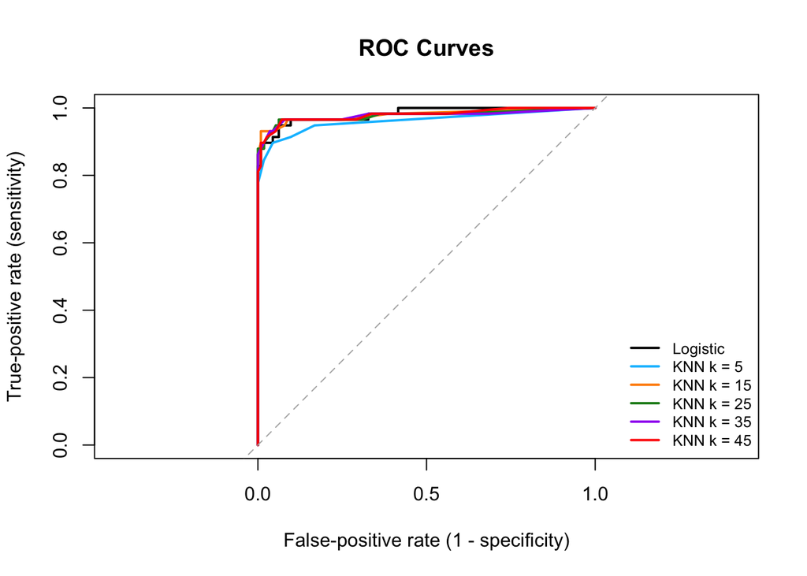

```r
data = read.csv("data/breast-cancer.csv")

set.seed(432)

predictors = c("mean_radius", "mean_texture", "mean_smoothness")

split_score = runif(nrow(data))
train_id = order(split_score)[1:floor(0.70 * nrow(data))]

train = data[train_id, ]
test = data[-train_id, ]

train_mean = colMeans(train[, predictors])
train_sd = apply(train[, predictors], 2, sd)

x_train = scale(train[, predictors],
                center = train_mean,
                scale = train_sd)

x_test = scale(test[, predictors],
               center = train_mean,
               scale = train_sd)

train_scaled = data.frame(y = train$y, x_train)
test_scaled = data.frame(y = test$y, x_test)

log_fit = glm(y ~ mean_radius + mean_texture + mean_smoothness,
              data = train_scaled,
              family = binomial())

p_log = predict(log_fit, newdata = test_scaled, type = "response")

library(class)

knn_probability = function(k) {
  fit = knn(train = x_train,
            test = x_test,
            cl = factor(train$y, levels = c(0, 1)),
            k = k,
            prob = TRUE)

  win_prob = attr(fit, "prob")
  ifelse(fit == "1", win_prob, 1 - win_prob)
}

k_values = c(5, 15, 25, 35, 45)
p_knn = lapply(k_values, knn_probability)

roc_values = function(y, p) {
  thresholds = c(Inf, sort(unique(p), decreasing = TRUE))
  tpr = fpr = numeric(length(thresholds))

  for (i in seq_along(thresholds)) {
    predicted = p >= thresholds[i]
    tpr[i] = mean(predicted[y == 1])
    fpr[i] = mean(predicted[y == 0])
  }

  auc = sum(diff(fpr) *
              (head(tpr, -1) + tail(tpr, -1)) / 2)

  list(fpr = fpr, tpr = tpr, auc = auc)
}

roc_log = roc_values(test$y, p_log)
roc_knn = lapply(p_knn, function(p) roc_values(test$y, p))

colors = c("black", "deepskyblue", "darkorange",
           "forestgreen", "purple", "red")

plot(roc_log$fpr, roc_log$tpr,
     type = "l", lwd = 2, col = colors[1],
     xlim = c(0, 1), ylim = c(0, 1), asp = 1,
     xlab = "False-positive rate (1 - specificity)",
     ylab = "True-positive rate (sensitivity)",
     main = "ROC Curves")

for (i in seq_along(k_values)) {
  lines(roc_knn[[i]]$fpr, roc_knn[[i]]$tpr,
        col = colors[i + 1], lwd = 2)
}

abline(0, 1, col = "gray70", lty = 2)

legend("bottomright",
       legend = c("Logistic", paste("KNN k =", k_values)),
       col = colors, lwd = 2, bty = "n", cex = 0.8)
```

```r
auc_values = c(
  Logistic = roc_log$auc,
  "KNN k = 5" = roc_knn[[1]]$auc,
  "KNN k = 15" = roc_knn[[2]]$auc,
  "KNN k = 25" = roc_knn[[3]]$auc,
  "KNN k = 35" = roc_knn[[4]]$auc,
  "KNN k = 45" = roc_knn[[5]]$auc
)

round(auc_values, 3)
```

```
  Logistic  KNN k = 5 KNN k = 15 KNN k = 25 KNN k = 35 KNN k = 45
     0.982      0.962      0.979      0.977      0.977      0.979
```

The seed used was 432. The test AUC values were 0.982 for logistic regression, 0.962 for KNN with k = 5, 0.979 for k = 15, 0.977 for k = 25, 0.977 for k = 35, and 0.979 for k = 45.

I would prefer logistic regression because it had the highest test AUC at 0.982. This means it did the best job of separating malignant and benign cases among the six fitted models.

## Question 2: Training and test ROC curves

Use the same data, training/test split, and standardization as in Question 1. Fit KNN with Euclidean distance, equal neighbor weights, and

$$k\in\{1,3,5,10,20\}.$$

Use each fitted model to estimate probabilities for both the training and test observations. For training predictions, include each observation itself among its $k$ nearest neighbors.

For each $k$, use a separate panel to show the training and test ROC curves together. Report both AUC values.

Explain the difference between training and test performance and how it changes with $k$. In particular, explain what happens at $k=1$ and why training performance may not reflect performance on new observations.

### Solution:

```r
library(FNN)
library(pROC)
k_values = c(1, 3, 5, 10, 20)

p_train = matrix(NA_real_, nrow(x_train), length(k_values))
p_test = matrix(NA_real_, nrow(x_test), length(k_values))

roc_train = vector("list", length(k_values))
roc_test = vector("list", length(k_values))

auc_train = numeric(length(k_values))
auc_test = numeric(length(k_values))

for (m in seq_along(k_values)) {
  k = k_values[m]

  p_train[, m] = knn.reg(
    train = x_train,
    test = x_train,
    y = train$y,
    k = k,
    algorithm = "brute"
  )$pred

  p_test[, m] = knn.reg(
    train = x_train,
    test = x_test,
    y = train$y,
    k = k,
    algorithm = "brute"
  )$pred

  roc_train[[m]] = roc(
    train$y, p_train[, m],
    levels = c(0, 1),
    direction = "<",
    quiet = TRUE
  )

  roc_test[[m]] = roc(
    test$y, p_test[, m],
    levels = c(0, 1),
    direction = "<",
    quiet = TRUE
  )

  auc_train[m] = as.numeric(auc(roc_train[[m]]))
  auc_test[m] = as.numeric(auc(roc_test[[m]]))
}

data.frame(
  k = k_values,
  Training_AUC = round(auc_train, 4),
  Test_AUC = round(auc_test, 4)
)
```

```
   k Training_AUC Test_AUC
1  1       1.0000   0.9089
2  3       0.9881   0.9548
3  5       0.9848   0.9618
4 10       0.9770   0.9794
5 20       0.9791   0.9786
```

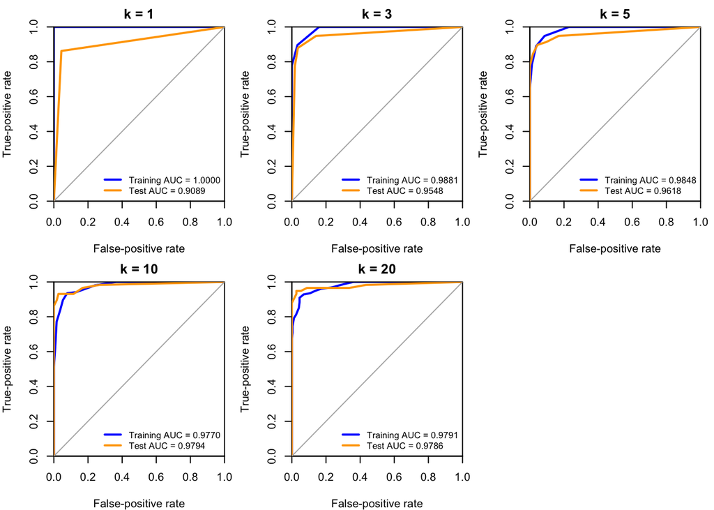

```r
old_par = par(mfrow = c(2, 3), mar = c(4, 4, 2, 1))

for (m in seq_along(k_values)) {
  plot(
    1 - roc_train[[m]]$specificities,
    roc_train[[m]]$sensitivities,
    type = "l",
    col = "blue",
    lwd = 2,
    xlim = c(0, 1),
    ylim = c(0, 1),
    xaxs = "i",
    yaxs = "i",
    main = paste("k =", k_values[m]),
    xlab = "False-positive rate",
    ylab = "True-positive rate"
  )

  lines(
    1 - roc_test[[m]]$specificities,
    roc_test[[m]]$sensitivities,
    col = "orange",
    lwd = 2
  )

  abline(0, 1, col = "gray70")

  legend(
    "bottomright",
    c(
      sprintf("Training AUC = %.4f", auc_train[m]),
      sprintf("Test AUC = %.4f", auc_test[m])
    ),
    col = c("blue", "orange"),
    lwd = 2,
    cex = 0.8,
    bty = "n"
  )
}

plot.new()
```

```r
par(old_par)
```

The training and test AUC values were 1.0000 and 0.9089 for k = 1, 0.9881 and 0.9548 for k = 3, 0.9848 and 0.9618 for k = 5, 0.9770 and 0.9794 for k = 10, and 0.9791 and 0.9786 for k = 20.

At k = 1, the training AUC is 1 because each training observation is included as its own nearest neighbor, so its predicted class matches its actual class. However, the test AUC is much lower because new observations cannot use their own labels when making predictions.

As k increases, the test AUC improves and the difference between training and test performance becomes much smaller. Using more neighbors makes the predictions less dependent on individual training observations and reduces overfitting. By k = 10 and k = 20, the training and test AUC values are nearly the same. This shows that very strong training performance, especially at k = 1, does not necessarily mean the model will perform equally well on new observations.

## Question 3: Peer evaluation of Homework 5

You will receive two Homework 5 submissions to review. The instructor’s GitHub account, **rqzhu-aide**, will open a **GitHub Issue** in the repository containing your Homework 5 submission. It will contain links to two other students’ repositories, where you can find their submitted homework reports.

Open your repository’s **Issues** tab on GitHub to find the assignment. You may ask AI to explain GitHub Issues or help you locate the assignment.

Choose **one specific mistake or item for improvement** from any question in either report.

1. **Identify the mistake or item for improvement.** State which report and question you selected, and briefly describe what is wrong or could be improved. Examples include incorrect code, a calculation error, a misinterpretation of results, a plot that could communicate the findings more clearly, or anything else you think could be done better.
2. **Explain your assessment.** Quote the relevant text, code, or figure caption exactly. Explain why the selected answer is incorrect or how it could be improved, referring to its reasoning, calculations, code, figures, or interpretation. **Complete this part yourself, without AI assistance.**
3. **Provide a correction.** Write a corrected or improved answer to the selected question, including any calculations, code, or figures needed.

After completing your review, **open a GitHub Issue in the repository containing the report you selected**. Identify the report and question, and include your assessment and a detailed revision plan explaining what the author should change and why. Include a link to your posted GitHub Issue in your Homework 6 answer.

### Solution:

#### 1. Identify the mistake or item for improvement

I reviewed **sophiastierwalt’s Homework 5 report** and selected **Question 1(b)**.

Report: [sophiastierwalt Homework 5](https://github.com/sophiastierwalt/stat432-fall2026/blob/main/homework/week-05/homework-05.html)

The item I selected for improvement is the calculation of mean squared error (MSE). In the report, the MSE is calculated using:

```r
mse = colMeans(test.pred - fx0)^2
```

The issue is that this code first calculates the average prediction error and then squares it. This gives the squared bias rather than the mean squared error.

###@ 2. Explain the assessment

The exact code from the report is:

```r
mse = colMeans(test.pred - fx0)^2
```

Mean squared error should calculate the squared error for each prediction first and then take the average. In other words, MSE should be calculated as

$$\text{MSE} = \frac{1}{200}\sum_{i=1}^{200}
\left(\hat{f}^{(i)}(x_0)-f(x_0)\right)^2.$$

The original code instead calculates

$$\left[
\frac{1}{200}\sum_{i=1}^{200}
\left(\hat{f}^{(i)}(x_0)-f(x_0)\right)
\right]^2,$$

which is the squared bias.

This is important because Question 1(b) asks us to verify that

$$\text{MSE} = \text{bias}^2 + \text{variance}.$$

Since the original `mse` calculation is actually squared bias, the MSE values and the MSE curve in the plot do not represent the true mean squared error.

The report also states:

> “They intersect at k = 20, so this might be a good value of k to use to minimize this trade-off.”

The point where squared bias and variance cross does not necessarily minimize MSE. The value of $k$ should instead be chosen by looking for the smallest value of

$$\text{bias}^2 + \text{variance}.$$

Using the values reported in the homework, the smallest value of $\text{bias}^2+\text{variance}$ occurs at $k=11$, where the estimated MSE is approximately $0.01298$.

#### 3. Provide a correction

The MSE calculation should be changed to:

```r
mse = colMeans((test.pred - fx0)^2)
```

The complete corrected calculations can be written as:

```r
bias = colMeans(test.pred) - fx0

variance = sapply(as.data.frame(test.pred), function(x) {
  mean((x - mean(x))^2)
})

mse = colMeans((test.pred - fx0)^2)

bias2 = bias^2
```

The relationship between MSE, squared bias, and variance can then be checked using:

```r
max(abs(mse - (bias2 + variance)))
```

This value should be approximately zero, apart from small numerical rounding error, which verifies

$$\text{MSE} = \text{bias}^2 + \text{variance}.$$

A corrected plot could then be produced using:

```r
plot(
  x = ks,
  y = mse,
  type = "l",
  col = "purple",
  ylim = range(c(mse, bias2, variance)),
  xlab = "k",
  ylab = "Estimated Error",
  main = "Bias-Variance Trade-off for KNN"
)

lines(
  x = ks,
  y = bias2,
  col = "blue"
)

lines(
  x = ks,
  y = variance,
  col = "red"
)

legend(
  "topright",
  legend = c("MSE", "Squared Bias", "Variance"),
  col = c("purple", "blue", "red"),
  lty = 1
)
```

The interpretation should also be revised. As $k$ increases, variance generally decreases while squared bias generally increases. The estimated MSE combines both quantities, so the best value of $k$ among the values tested is the one with the smallest estimated MSE. From the values reported in the homework, this occurs at approximately $k=11$, with an estimated MSE of $0.01298$.

### GitHub Issue

I posted my peer evaluation and revision plan as a GitHub Issue in the repository containing the report.

GitHub Issue: [Homework 5 Question 1(b): MSE calculation](https://github.com/sophiastierwalt/stat432-fall2026/issues/2)